# M2.883_2022_1_PEC2-Enunciado

[figure not shown]

M2.883 · Aprendizaje por refuerzo

Máster universitario en Ciencia de datos (*Data science*)

Estudios de Informática, Multimedia y Telecomunicación

# PEC2: Deep Reinforcement Learning

En esta práctica se implementarán tres modelos de DRL en un mismo entorno, con el objetivo de analizar distintas formas de aprendizaje de un agente y estudiar su rendimiento. El agente será entrenado con los métodos:

1. DQN
2. Dueling DQN
3. REINFORCE with baseline

**Importante: La entrega debe hacerse en formato notebook y en formato html donde se vea el código y los resultados y comentarios de cada ejercicio. Para exportar el notebook a html puede hacerse desde el menú File → Download as → HTML.**

**Es necesario adjuntar en la entrega los ficheros .pth con los diferentes modelos entrenados.**

No es necesario adjuntar los ficheros .gif

**Javier Gómez de Diego**

## 0. Contexto

Uno de los objetivos más actuales del campo de la robótica es conseguir que un robot sea capaz de aprender a realizar una serie de acciones por si sólo, del mismo modo que lo hace un niño pequeño. Esta es, básicamente, una de las principales motivaciones del aprendizaje por refuerzo profundo. Para ello se necesitan sistemas de control eficientes en entornos de alta dimensionalidad como puede ser la inversión en bolsa, conducción de coches autónomos o, incluso, el control de cohetes espaciales. Con esta idea, en esta práctica usaremos un entorno ya predefinido en OpenAI, **Space Invader**.

**Space Invader** consiste en un cañón que puede disparar hacia arriba y moverse de izquierda a derecha. El objetivo del juego es destruir a los extraterrestres enemigos, que se acercan cada vez más rápido al jugador a medida que este los elimina, y maximiza la puntuación. En este entorno, la observación es una imagen RGB de la pantalla representada por una matriz de forma (210, 160, 3) cómo se observa a continuación.

[figure not shown]

Rango de acciones:

- NOOP: 0 ( No operacion).
- FIRE: 1 (disparar sin moverse)
- RIGHT: 2 (mover a la derecha)
- LEFT: 3 (mover a la izquierda)
- RIGHTFIRE: 4 (disparar y mover a la derecha)
- LEFTFIRE: 5 (disparar y mover a la izquierda)

Recompensa: La recompensa devuelta por el entorno está compuesta por un valor en el rango [0, 30]. Dependiendo de la nave alienígena destruida, el agente recibe una puntuación diferente. Nuestra tarea es enseñarle una política que le permita hacer una elección "buena" para cada estado.

Para más detalles sobre la definición del entorno de Space Invader, se recomienda consultar las web: https://www.gymlibrary.dev/environments/atari/space_invaders/ y https://atariage.com/manual_html_page.php?SoftwareLabelID=460

## 1. Inicialización y exploración del entorno (1 pto)

**IMPORTANTE**: el entorno Space Invader depende de la instalación de los siguientes paquetes

- gym[atari] en la versión 0.25.0
- autorom[accept-rom-license]

Este entorno puede ser ejecutado tanto en local como en Kaggle con la versión de GPU P100 y en Google Colab. Recomiendo utlizar Kaggle para los estudiantes que no dispongan de una GPU en local.

Empezaremos cargando las principales librerías necesarias para la práctica:

```python
#instalación de librerías.
import warnings
warnings.filterwarnings('ignore')
import time
!pip install gym[atari]==0.25.0
!pip install autorom[accept-rom-license]
!pip install imageio
!pip install matplotlib
!pip install torch
import gym
import torch
import matplotlib.pyplot as plt
from ale_py import ALEInterface
ale = ALEInterface()
from ale_py.roms import SpaceInvaders
ale.loadROM(SpaceInvaders)
import numpy as np
import os
import imageio
from PIL import Image
import PIL.ImageDraw as ImageDraw
!pip install scikit-image
from skimage import transform
import torch
import torch.nn as nn
import torch.autograd as autograd
import torch.optim as optim
```

```python
# Comprobación de la versión de GYM instalada
print('La versión de gym instala: ' + gym.__version__)
# Comprobación de entorno con gpu
device = torch.device("cuda" if torch.cuda.is_available() else "cpu")
print("El entorno utiliza: ", device)
```

```
La versión de gym instala: 0.25.0
El entorno utiliza:  cpu
```

Comprueba que la celda anterior indica que la verisón instalada de Gym es la 0.25.0.

**Ejercicio 1.1 (0.2 ptos):** Inicializar el entorno 'SpaceInvaders-v4'. Extraer:

- Valor del umbral de recompensa definido en el entorno
- Máximo número de pasos establecidos para cada episodio
- La dimensión del espacio de acciones
- La dimensión del espacio de observaciones.

```python
warnings.filterwarnings('ignore')
env = gym.make('SpaceInvaders-v4')

print('Umbral de recompensa definido: \033[1m{}\033[0m'.format(env.spec.reward_threshold))
print('Nº máximo de pasos para cada episodio: \033[1m{}\033[0m'.format(env.spec.max_episode_steps))
print('Diemsnión del espacio de acciones: \033[1m{}\033[0m'.format(env.action_space))
print('Diemsnión del espacio de observaciones: \033[1m{}\033[0m'.format(env.observation_space))
```

```
Umbral de recompensa definido: None
Nº máximo de pasos para cada episodio: 100000
Diemsnión del espacio de acciones: Discrete(6)
Diemsnión del espacio de observaciones: Box(0, 255, (210, 160, 3), uint8)
```

En el aprendizaje por refuerzo suele ser muy útil visualizar el comportamiento de un agente en su entorno. Para esta PEC es interesante poder almacenar el comportamiento visual de un agente en forma de archivo .gif.

**Ejercicio 1.2 (0.2 ptos):** En este ejericicio os proponemos almacenar en una carpeta videos un ejemplo de actuación del agente aleatorio en forma de archivo .gif.  
-----------------------------------------------------------------------------------------------------------  
**Nota**: se os proporciona el código pre-implementado. La implementación que se pide en el enunciado está indicada en los bloques *TODO* y/o con variables igualadas a *None*.

```python
#Método para generar la imagen a partir de un estado con un texto informativo.
def _label_with_text(frame):
    '''
    frame: estado de un entorno GYM.
    '''
    im = Image.fromarray(frame)
    im = im.resize((im.size[0]*2,im.size[1]*2))
    drawer = ImageDraw.Draw(im)
    drawer.text((1, 1), "Uoc Aprendizaje Por Refuerzo.", fill=(255, 255, 255, 128))
    return im

#Método que permite crear un gif con la evolución de una partida dado un entorno GYM.
def save_random_agent_gif(env):
    frames = []
    done = False
    env.reset()

    while not done:
        action = env.action_space.sample()
        frame = env.render(mode='rgb_array')
        frames.append(_label_with_text(frame))
        state, _, done, _ = env.step(action)

    env.close()
    imageio.mimwrite(os.path.join('./videos/', 'random_agent_space_invader_usuario.gif'), frames, fps=60)
```

```python
env = gym.make('SpaceInvaders-v4', render_mode='rgb_array')
try:
    os.makedirs('videos')
except:
    pass
save_random_agent_gif(env)
```

**Ejercicio 1.3 (0.3 ptos):** Ejecutar 1000 episodios con el máximo de pasos establecido en el entorno de Space Invader, tomando acciones de forma aleatoria. Almacenar la suma de recompensas de cada partida y la cantidad de episodios ejecutados. Mostrar:

- Histograma con la suma de recompensas de cada partida
- Histograma con la cantidad de pasos para resolver cada partida.

```python
def play_random_episodes(episodios = 1000):
    env = gym.make('SpaceInvaders-v4', render_mode='rgb_array')
    rewards = []
    pasos = []

    for i in range(episodios):
        done = False
        p = 0
        r = 0
        env.reset()

        while not done and p < env.spec.max_episode_steps:
            action = env.action_space.sample()
            state, reward, done, _ = env.step(action)
            r += reward
            p += 1

        rewards.append(r)
        pasos.append(p)

        print("Episodio {} de {}".format(i, episodios), end = '\r')

    print("Episodio {} de {}".format(episodios, episodios), end = '\r')
    env.close()
    return pasos, rewards
```

```python
pasos, rewards = play_random_episodes()
```

```
Episodio 1000 de 1000
```

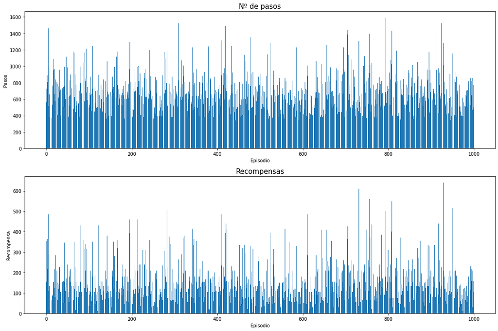

```python
fig, ax = plt.subplots(2, 1, figsize=(15, 10))
x = [i for i in range(len(pasos))]

ax[0].bar(x, pasos)
ax[0].set_title('Nº de pasos', fontsize=15)
ax[0].set_xlabel('Episodio')
ax[0].set_ylabel('Pasos')
ax[1].bar(x, rewards)
ax[1].set_title('Recompensas', fontsize=15)
ax[1].set_xlabel('Episodio')
ax[1].set_ylabel('Recompensa')

plt.tight_layout()
```

**Análisis (0.3 ptos):** ¿Cuál es la media de recompensas obtenida? ¿Y la media de pasos por episodio? Comenta los resultados obtenidos.

```python
print('Media de la recompensa obtenida: \033[1m{}\033[0m'.format(np.mean(rewards)))
print('Media de los pasos ejecutados: \033[1m{}\033[0m'.format(np.mean(pasos)))
```

```
Media de la recompensa obtenida: 152.06
Media de los pasos ejecutados: 684.476
```

**Solución:**  
Con 1.000 partidas jugadas de forma aleatoria (sin ningún criterio para elegir las acciones a ejecutar en cada estados) nos hacemos una idea de la recompensa y el número de pasos base: *150* aprox. para la primera y *700* pasos aprox. por episodio. Por lo tanto, las políticas que desarrollemos deberán estar por encima de estas estimaciones para considerarlas útiles ya que, de lo contrario, una política totalmente aleatoria sería mejor.  
Además, observando las gráficas, podemos intuir una correlación entre el número de episodios jugados por partida y la recompensa obtenida: cuanto mayor sea el primero, mayor será la segunda. Por lo tanto, una de las características de una buena política podrá ser maximizar el número de pasos por episodio.

## 2. Agente DQN (2.8 ptos)

En este apartado implementaremos una solución DQN para intentar obtener un modelo que nos permita solucionar este entorno. Primeramente definiremos el modelo de red neuronal, luego describiremos el comportamiento del agente, lo entrenaremos y, finalmente, testearemos el funcionamiento del agente entrenado.

### 2.1 Procesamiento de las observaciones.

El primer paso es entender la estructura de la información que nos proporciona el entorno. Los juegos de Atari utilizan un espacio de acción con una estructura de la siguiente forma (210, 160, 3), es decir, 210 pixeles de anchura, 160 de altura y 3 colores (RGB). Cada uno de estos puntos de la estructura es un pixel de color y posee un rango de valores que van desde el 0 hasta 255, lo que nos da $256^{(210x160x3)}$ = $256^{100800}$ posibilidades (a modo de comparación, tenemos aproximadamente $10^{80}$ átomos en el universo observable)

[figure not shown]

Fuente: https://huggingface.co/blog/deep-rl-dqn

**2.1 Análisis (0.2 pto):** ¿Es posible implementar una solución tabular vista durante la PEC1 en este entorno de Space Invader?

**Respuesta:**  
**No**. Para implementar una solución tabular habría que mapear todos y cada uno de los posibles estados para calcular la función de valor de estado o la función de valor estado-acción. Con este número ingente de posibles estados, es absolutamente inviable optar por esta vía al requerir una cantidad de recursos inimaginalbe.

En este caso, la mejor idea es, dado un estado, aproximar los valores Q para cada posible acción en ese estado. Es decir, implementaremos la solución que puedes observar en la siguiente figura.

[figure not shown]

Fuente: https://huggingface.co/blog/deep-rl-dqn

Ahora bien, en el juego Space Invader no todo el espacio posee utilidad. El marcador, el marco o la cantidad de vidas no es necesario para el desarrollo del juego. Una práctica muy habitual en el aprendizaje por refuerzo es reducir las dimensiones del entorno con el objetivo de disminuir la cantidad de cálculos necesarios para obtener un modelo útil para el entorno.

Exactamente, para esta PEC os vamos a pedir reducir el espacio de los frames a 84 x 84 píxeles, reducir nuestros tres canales de color (RGB) a 1 (blanco y negro), normalizar el resultado y, por último, almacenar los 4 últimos frames cómo se muestra en la siguiente figura:

[figure not shown]

Fuente: https://huggingface.co/blog/deep-rl-dqn

**Ejercicio 2.2 (0.1 pto):** Define el metodo scale_lumininance para, dado un estado, transformar los puntos del sistema RGB al sistema binario blanco y negro

```python
def scale_lumininance(obs):

    return np.dot(obs[...,:3], [299/1000, 587/1000, 114/1000]) # R * 299/1000 + G * 587/1000 + B * 114/1000 -> https://pillow.readthedocs.io/en/stable/reference/Image.html#PIL.Image.Image.convert
```

**Ejercicio 2.3 (0.1 pto):** Define el metodo resize para, dado un estado, redimensionar su tamaño a 84 * 84

```python
def resize(obs):
    img = Image.fromarray((obs).astype(np.uint8))

    return np.array(img.resize(size=(84, 84)))
```

**2.4 Ejercicio (0.1 pto):** Define el metodo normalize para, dado un estado, normalice la imagen

```python
def normalize(obs):

    return np.dot(obs, 1/255)
```

El resultado que vas a obtener será el siguiente:

| 1.scale_lumininance(obs) | 2.resize(obs) | 3.normalize(obs) |
| --- | --- | --- |

[figure not shown]

```python
env.reset()
obs, _, _, _ = env.step(env.action_space.sample())

fig, ax = plt.subplots(1, 4, figsize=(15, 20))

ax[0].imshow(obs)
ax[0].set_title('Original', fontsize=15)

scaled = scale_lumininance(obs)
ax[1].imshow(scaled, cmap = 'gray')
ax[1].set_title('Escala de grises', fontsize=15)

resized = resize(scaled)
ax[2].imshow(resized, cmap = 'gray')
ax[2].set_title('Reducida', fontsize=15)

normalized = normalize(resized)
ax[3].imshow(normalized, cmap = 'gray')
ax[3].set_title('Normalizada', fontsize=15)

plt.tight_layout()
```

```python
env.render(mode='rgb_array')
action = env.action_space.sample()
state, reward, done, _ = env.step(action)

# Función que realiza todo el pre-procesado de una observación
def preprocess_observation(obs):
    obs_proc = scale_lumininance(obs)
    obs_proc = resize(obs_proc)
    obs_proc = normalize(obs_proc)
    return obs_proc
```

Por último, ¿cómo interpretamos el movimiento? Las imágenes corresponden a información estática de las partidas y, en este entorno, es importante conocer la dirección del disparo o el movimiento de los invasores. Para ello, una forma de gestionar esta información es apilando fotogramas para poder proporcionar al algoritmo información acerca de la progresión de la partida.

Utilicemos un ejemplo muy claro, el Ping Pong:

[figure not shown]

Fíjate cómo la pelota se desplaza hacia la derecha. La agrupación de los frames nos permite trasladar la información espacial a nuestro algoritmo.

**Ejercicio 2.5 (0.1 ptos):** Implementa la función stack_frame para apilar 4 frames de una partida. Dicha función debe apilar inicialmente (cuando is_new = True) el mismo frame 4 veces para, posteriormente, conforme se vayan introduciendo nuevos frames ir substituyendo a los más antiguos.

```python
def stack_frame(stacked_frames, frame, is_new):
        """Stacking Frames.
        Params
        ======
            stacked_frames (array): array de frames (al devolverlo debe tener 4 frames)
            frame: Nueva imagen a añadir (hay que borrar la más antigua)
            is_new: Primera vez que se utiliza el array.
        """
        if is_new:
            stacked_frames = []
            for i in range(4):
                stacked_frames.append(frame)
        else:
            stacked_frames.pop(0)
            stacked_frames.append(frame)

        return stacked_frames
```

Una vez creada la función la testeamos jugando una partida, almacenando los 4 frames más recientes en cada paso, y finalmente mostramos los 4 últimos frames de la partida.

[figure not shown]

```python
# Llenamos 'state_stack' con 4 copias idénticas del frame inicial de la partida
state_stack= stack_frame(None, env.reset(), True)

# Jugamos una partida aleatoria y vamos actualizando los 4 frames de 'state_stack'
# conforme se van produciendo nuevos
while True:
    action = env.action_space.sample()
    next_state, reward, done, info = env.step(action)
    state_stack = stack_frame(state_stack, next_state, False)

    if done:
         break

# Mostramos los últimos 4 frames de la partida que han quedado almacenados en 'state_stack'
fig = plt.figure(figsize=(10, 7))
rows = 2
columns = 2
cont=1

for i in state_stack:
    fig.add_subplot(rows, columns, cont)
    plt.imshow(i)
    plt.axis('off')
    plt.title('Fotograma:' + str(cont))
    cont = cont +1
```

Ahora con estas modificaciones podemos pasar al siguiente punto, la creación de la Red

[figure not shown]

Fuente: https://huggingface.co/blog/deep-rl-dqn

Cómo se observa en la imagen, utilizaremos un modelo convolucional (perfecto para detectar patrones en imágenes) junto con un sistema lineal completamente conectado. Para la red convolucional os proponemos la siguiente configuración:

- Una primera capa del tipo Conv2d con los siguientes parámetros in_channels=4, out_channels=32, kernel_size=8, stride=4 con activación ReLU.
- Una segunda capa del tipo Conv2d con los siguientes parámetros in_channels=32, out_channels=64, kernel_size=4, stride=2 con activación ReLU.
- Una tercera capa del tipo Conv2d con los siguientes parámetros in_channels=64, out_channels=64, kernel_size=3, stride=1 con activación ReLU.

El resultado de esta primera red (3D) lo conectaremos con un modelo complementamente conectado (1D) con la siguiente estructura lineal:

- Una primera capa completamente conectada (representada en pytorch por nn.Lineal) de 512 neuronas, con activación ReLU
- Una última capa completamente conectada. Esta será nuestra capa de salida y, por lo tanto, tendrá tantas neuronas como dimensiones tenga nuestro espacio de acciones (una salida por cada acción posible).

Por último, usaremos el optimizador Adam para entrenar la red.

**Ejercicio 2.6 (0.5 ptos):**Implementar la clase `DQN_CNN()`. Inicializar las variables necesarias y definir el modelo CNN y linial indicado.  
-----------------------------------------------------------------------------------------------------------  
**Nota**: se os proporciona el código pre-implementado. La implementación que se pide en el enunciado está indicada en los bloques *TODO* y/o con variables igualadas a *None*.

```python
import torch.nn as nn
class DQN_CNN(nn.Module):

    def __init__(self, env, learning_rate=1e-3):
        super(DQN_CNN, self).__init__()
        """
        Params
        ======
        n_inputs: tamaño del espacio de estados
        n_outputs: tamaño del espacio de acciones
        actions: array de acciones posibles
        device: cpu o cuda
        red_cnn: definición de la red convolucional
        red_lineal: definición de la red lineal
        """
        #######################################
        ###TODO: inicialización y modelo###
        self.input_shape = (4, 84, 84)
        self.n_outputs = env.action_space.n
        self.actions = [i for i in range(env.action_space.n)]

        if torch.cuda.is_available():
            self.device = 'cuda'
        else:
            self.device = 'cpu'

        #######################################
        ##TODO: Construcción de la red neuronal convolucional
        self.red_cnn = nn.Sequential(

            nn.Conv2d(in_channels = 4, out_channels = 32, kernel_size = 8, stride = 4),
            nn.ReLU(),
            nn.Conv2d(in_channels = 32, out_channels = 64, kernel_size = 4, stride = 2),
            nn.ReLU(),
            nn.Conv2d(in_channels = 64, out_channels = 64, kernel_size = 3, stride = 1),
            nn.ReLU()

        )

        if torch.cuda.is_available():
            self.red_cnn.cuda()

        self.fc_layer_inputs = self.feature_size()
        #######################################
        ##TODO: Construcción de la red neuronal lineal completamente conectada
        self.red_lineal = nn.Sequential(

            nn.Linear(self.fc_layer_inputs, 512),
            nn.ReLU(),
            nn.Linear(512, self.n_outputs)

        )

        if torch.cuda.is_available():
            self.red_lineal.cuda()

        #######################################
        ##TODO: Inicializar el optimizador
        self.optimizer = optim.Adam(params = self.parameters(), lr=learning_rate)

    ### e-greedy method
    def get_action(self, state, epsilon=0.05):
        if np.random.random() < epsilon:
            action = np.random.choice(self.actions)
        else:
            qvals = self.get_qvals(state)
            action= torch.max(qvals, dim=-1)[1].item()
        return action

    def get_qvals(self, state):
        if type(state) is tuple:
            state = np.array(state)
        state_t = torch.FloatTensor(state).to(device=self.device)
        cnn_out = self.red_cnn(state_t).reshape(-1,  self.fc_layer_inputs)
        return self.red_lineal(cnn_out)


    def feature_size(self):
        return self.red_cnn(autograd.Variable(torch.zeros(1, *self.input_shape)).to(device=self.device)).view(1, -1).size(1)
```

Definimos la clase para el *buffer* de repetición de experiencias:

```python
from collections import namedtuple, deque

class experienceReplayBuffer:
    def __init__(self, memory_size=50000, burn_in=10000):
        self.memory_size = memory_size
        self.burn_in = burn_in
        self.buffer = namedtuple('Buffer',
                                 field_names=['state', 'action', 'reward', 'done', 'next_state']
                                )
        self.replay_memory = deque(maxlen=memory_size)

    def sample_batch(self, batch_size=32):
        samples = np.random.choice(len(self.replay_memory),
                                   batch_size,
                                   replace=False
                                  )
        # Use el operador asterisco para desempaquetar deque
        batch = zip(*[self.replay_memory[i] for i in samples])
        return batch

    def append(self, state, action, reward, done, next_state):
        self.replay_memory.append(
            self.buffer(state, action, reward, done, next_state))

    def burn_in_capacity(self):
        return len(self.replay_memory) / self.burn_in
```

### 2.2 Definición del agente

A continuación implementaremos una clase que defina el entrenamiento del agente teniendo en cuenta:

- La exploración/explotación (decaimiento de epsilon)
- La actualización y sincronización de la red principal y la red objetivo (pérdida)

Además, vamos a considerar que el agente ha superado el entorno cuando obtenga una puntuación superior a 350 en 100 partidas

**Ejercicio 2.7 (1 pto):** Implementar los siguientes puntos de la clase `DQNAgent()`:

1. Declarar las variables de la clase
2. Inicializar las variables necesarias
3. Implementar la acción a tomar
4. Actualizar la red principal según la frecuencia establecida en los hiperparámetros
5. Calcular la ecuación de Bellman
6. Sincronizar la red objetivo según la frecuencia establecida en los hiperparámetros
7. Calcular la media de recompensas de los últimos 100 episodios
8. Actualizar epsilon según: $$\textrm{max}(\epsilon · \epsilon_{\textrm{decay}}, 0.01)$$

Además, durante el proceso se deben almacenar (*):

- Las recompensas obtenidas en cada paso del entrenamiento
- Las recompensas medias de los 100 episodios anteriores
- La pérdida durante el entrenamiento
- La evolución de epsilon a lo largo del entrenamiento

-----------------------------------------------------------------------------------------------------------  
**Nota**: se os proporciona el código pre-implementado. La implementación que se pide en el enunciado está indicada en los bloques *TODO* y/o con variables igualadas a *None*, salvo (*) en qué momento almacenar las variables que se indican.

```python
from copy import deepcopy, copy
class DQNAgent:
    ###################################################
    ######TODO 1: declarar variables ##################
    def __init__(self, env, main_network,
                 buffer, reward_threshold=350,
                 epsilon=0.1, eps_decay=0.99, batch_size=32, nblock=100):
        """"
        Params
        ======
        env: entorno
        main_network: clase con la red neuronal diseñada
        target_network: red objetivo
        buffer: clase con el buffer de repetición de experiencias
        epsilon: epsilon
        eps_decay: epsilon decay
        batch_size: batch size
        nblock: bloque de los X últimos episodios de los que se calculará la media de recompensa
        reward_threshold: umbral de recompensa
        """
        if torch.cuda.is_available():
            self.device = 'cuda'
        else:
            self.device = 'cpu'
        self.env = env
        self.main_network = main_network
        self.target_network = deepcopy(main_network) # red objetivo (copia de la principal)
        self.buffer = buffer
        self.epsilon = epsilon
        self.eps_decay = eps_decay
        self.batch_size = batch_size
        self.nblock = nblock
        self.reward_threshold = reward_threshold
        self.initialize()

    ###############################################################
    #####TODO 2: inicialitzar variables extra que es necesiten######
    def initialize(self):
        self.sync_eps = []
        self.total_reward = 0
        self.step_count = 0
        incio_juego = preprocess_observation(self.env.reset())
        self.state0 = stack_frame(None, incio_juego, True)
        self.update_loss = []
        self.epsilons = []
        self.training_rewards = []
        self.losses = []


    #################################################################################
    ######TODO 3:  Tomar nueva acción ###############################################
    def take_step(self, eps = 0.05, mode='train'):
        if mode == 'explore':
            action = self.env.action_space.sample()  # acción aleatoria en el burn-in
        else:
            action = self.main_network.get_action(self.state0, eps)# acción a partir del valor de Q (elección de la acción con mejor Q)
            self.step_count += 1

        #TODO: Realización de la acción y obtención del nuevo estado y la recompensa.
        new_state, reward, done, _ = env.step(action)
        new_state = stack_frame(self.state0, preprocess_observation(new_state), False) #Recordar preprocesar los estados
        self.total_reward += reward
        self.buffer.append(self.state0, action, reward, done, new_state) # guardar experiencia en el buffer
        self.state0 = new_state

        #TODO: resetear entorno 'if done'
        if done:
            self.state0 = stack_frame(None, preprocess_observation(self.env.reset()), True) #Recordar preprocesar los estados
        return done



    ## Entrenamiento
    def train(self, gamma=0.99, max_episodes=50000,
              batch_size=32,
              dnn_update_frequency=4,
              dnn_sync_frequency=2000, min_episodios=250, min_epsilon = 0.01):
        self.gamma = gamma
        # Rellenamos el buffer con N experiencias aleatorias ()
        print("Filling replay buffer...")
        while self.buffer.burn_in_capacity() < 1:
            self.take_step(self.epsilon, mode='explore')

        episode = 0
        training = True
        print("Training...")
        maximo = 0
        while training:
            self.state0 = stack_frame(None, preprocess_observation(self.env.reset()), True) #Recordar preprocesar los estados
            self.total_reward = 0
            gamedone = False
            while gamedone == False:
                # El agente toma una acción
                gamedone = self.take_step(self.epsilon, mode='train')

                #################################################################################
                ###TODO 4: Actualizar red principal según la frecuencia establecida#####
                if self.step_count % dnn_update_frequency == 0:
                    self.update()

                ########################################################################################
                ###TODO 6: Sincronizar red principal y red objetivo según la frecuencia establecida#####
                if self.step_count % dnn_sync_frequency == 0:
                    self.target_network.load_state_dict(self.main_network.state_dict())

                if gamedone:
                    episode += 1
                    ##################################################################
                    ########TODO: Almacenar epsilon, training rewards y loss#######
                    self.epsilons.append(self.epsilon)
                    self.training_rewards.append(self.total_reward)
                    self.losses.append(self.update_loss)

                    ##################################################################

                    self.update_loss = []


                    #######################################################################################
                    ###TODO 7: calcular la media de recompensa de los últimos X episodios, y almacenar#####
                    mean_rewards = np.mean(self.training_rewards[-nblock:])
                    maximo = max(self.training_rewards[-nblock:])
                    ##################################################################

                    print("\rEpisode {:d} Mean Rewards {:.2f} Epsilon {} , Maximo {:.2f}\t\t".format(
                        episode, mean_rewards, self.epsilon, maximo), end="")

                    # Comprobar si se ha llegado al máximo de episodios
                    if episode >= max_episodes:
                        training = False
                        print('\nEpisode limit reached.')
                        break


                    # Termina el juego si la media de recompensas ha llegado al umbral fijado para este juego
                    # y se ha entrenado un mínimo de episodios
                    if mean_rewards >= self.reward_threshold and min_episodios <  episode:
                        training = False
                        print('\nEnvironment solved in {} episodes!'.format(
                            episode))
                        break

                    #################################################################################
                    ######TODO 8: Actualizar epsilon ########
                    self.epsilon = max(self.epsilon * self.eps_decay, min_epsilon)


    ####################################
    #####TODO 5: Cálculo de la pérdida ####
    def calculate_loss(self, batch):
        # Separamos las variables de la experiencia y las convertimos a tensores
        states, actions, rewards, dones, next_states = [i for i in batch]
        rewards_vals = torch.FloatTensor(rewards).to(device=self.device)
        actions_vals = torch.LongTensor(np.array(actions)).to(device=self.device).reshape(-1,1)
        dones_t = torch.ByteTensor(dones).to(device=self.device)

        # Obtenemos los valores de Q de la red principal
        qvals = torch.gather(self.main_network.get_qvals(states), 1, actions_vals)

        # Obtenemos los valores de Q de la red objetivo. El parametro detach() evita que estos valores actualicen la red objetivo
        qvals_next = torch.max(self.target_network.get_qvals(next_states),
                               dim=-1)[0].detach()
        qvals_next[dones_t] = 0 # 0 en estados terminales

        #################################################################################
        ###TODO: Calculamos ecuación de Bellman
        expected_qvals = rewards_vals + self.gamma * qvals_next


        loss = torch.nn.MSELoss()(qvals, expected_qvals.reshape(-1,1))
        return loss


    def update(self):
        self.main_network.optimizer.zero_grad()  # eliminamos cualquier gradiente pasado
        batch = self.buffer.sample_batch(batch_size=self.batch_size) # seleccionamos un conjunto del buffer
        loss = self.calculate_loss(batch)# calculamos la pérdida
        loss.backward() # hacemos la diferencia para obtener los gradientes
        self.main_network.optimizer.step() # aplicamos los gradientes a la red neuronal
        # Guardamos los valores de pérdida
        if self.device == 'cuda':
            self.update_loss.append(loss.detach().cpu().numpy())
        else:
            self.update_loss.append(loss.detach().numpy())
```

### 2.3 Entrenamiento

A continuación entrenaremos el modelo con los siguientes hiperparámetros:

- Velocidad de aprendizaje: 0.001
- Tamaño del batch: 32
- Capacidad máxima del buffer: 8000
- Gamma: 0.99
- Epsilon: 1, con decaimiento de 0.995 con un mínimo de 0.01
- Número de steps para rellenar el buffer: 100
- Número máximo de episodios: 5000
- Número minímo de episodios: 250
- Frecuencia de actualización de la red neuronal: 100
- Frecuencia de sincronización con la red objetivo: 5000

Es probable que con los hiperparámetros propuestos no se llegue a solucionar el entorno (conseguir una puntuación de 350 en la media de 100 partidas). El objetivo principal es mejorar los resultados del agente aleatorio.

Está permitido realizar modificaciones en los parámetros presentados aunque, el último ejercicio de esta PEC, consiste en mejorar los resultados obtenidos con este entrenamiento. Por lo tanto, aunque esté permitido, no es recomendable.

Si el alumno no dispone de suficiente tiempo puede acortar el tiempo de entrenamiento fijando el Número máximo de episodios = 3000 en lugar de los 5000 propuestos.

**Ejercicio 2.8 (0.1 ptos):** Declarar los hiperparámetros, cargar el modelo de red neuronal y entrenar el agente

```python
lr = 0.001
batch = 32
max_buffer = 8000
gamma = 0.99
epsilon = 1
eps_decay = 0.995
eps_min = 0.01
steps_buffer = 100
max_episodes = 3000
min_episodes = 250
frec_upd = 100
frec_sync = 5000
reward_threshold = 350
nblock = 100

network = DQN_CNN(env = env,
                  learning_rate = lr
                 )

buffer = experienceReplayBuffer(memory_size = max_buffer,
                                burn_in = steps_buffer
                               )

agent = DQNAgent(env = env,
                 main_network = network,
                 buffer = buffer,
                 reward_threshold = reward_threshold,
                 epsilon = epsilon,
                 eps_decay = eps_decay,
                 batch_size = batch,
                 nblock = nblock
                 )

agent.train(gamma = gamma,
            max_episodes = max_episodes,
            batch_size = batch,
            dnn_update_frequency = frec_upd,
            dnn_sync_frequency = frec_sync,
            min_episodios = min_episodes,
            min_epsilon = eps_min
           )
```

```
Filling replay buffer...
Training...
Episode 3000 Mean Rewards 243.90 Epsilon 0.01 , Maximo 800.00			aximo 490.00
Episode limit reached.
```

**Ejercicio 2.9 (0.1 ptos):** Representar:

1. Gráfico con las recompensas obtenidas a lo largo del entrenamieno, la evolución de las recompensas medias y el umbral de recompensa establecido por el entorno.
2. Gráfico con la evolución de la perdida a lo largo del entrenamiento
3. Gráfico con la evolución de epsilon a lo largo del entrenamiento

```python
dqn_rewards = agent.training_rewards
dqn_mean_rewards = []
for i in range(1, len(dqn_rewards)):
    if i < agent.nblock:
        dqn_mean_rewards.append(sum(dqn_rewards[0:i])/i)
    else:
        dqn_mean_rewards.append(sum(dqn_rewards[(i-agent.nblock):i])/agent.nblock)

dqn_reward_threshold = agent.reward_threshold
dqn_losses = agent.losses
dqn_epsilons = agent.epsilons
```

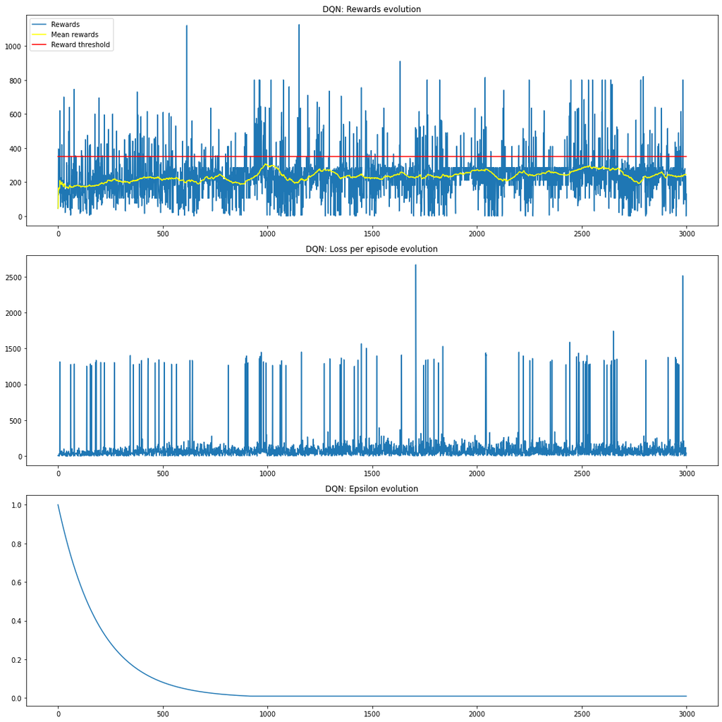

```python
fig, ax = plt.subplots(3, 1, figsize=(15, 15))

ax[0].set_title('DQN: Rewards evolution')
ax[0].plot(dqn_rewards)
ax[0].plot(dqn_mean_rewards, color='yellow')
ax[0].plot([dqn_reward_threshold for i in range(len(dqn_rewards))], color = 'red')
ax[0].legend(['Rewards', 'Mean rewards', 'Reward threshold'], loc = 'upper left')

ax[1].set_title('DQN: Loss per episode evolution')
ax[1].plot([sum(i) for i in dqn_losses])
#ax[1].ylim(0,40)

ax[2].set_title('DQN: Epsilon evolution')
ax[2].plot(dqn_epsilons)

plt.tight_layout()
```

**Ejercicio 2.10 (0.1 ptos):** Comenta los resultados

**Solución:**  
La evolución de las recompensas y la pérdida no muestran una gran efectividad del entrenamiento. A medida que la explotación comienza a tener más importancia (epsilon decae), se aprecia una muy ligera mejora de las recompensas. Sin embargo, a partir de este momento éstas se vuelven más volátiles y, en el cómputo global, no logran mejorar. En cuanto a la pérdida, podría parecer que es aleatoria (incluso con *outliers* muy marcados), por lo que no se aprecia mejora alguna a lo largo del entrenamiento.

**Ejercicio 2.11 (0.1 pto):** Guardar el modelo entrenado en formato ".pth".

```python
torch.save(agent.main_network.state_dict(), 'agentDQN_Trained_Model_dqn_cnn.pth')
```

### 2.4 Test del agente entrenado

Una vez entrenado el agente, nos interesa comprobar cómo de bien ha aprendido, si el "robot" es capaz de realizar las tareas aprendidas. Para ello, recuperamos el modelo entrenado y dejamos que el agente tome acciones aleatorias según ese modelo y observamos su comportamiento.

**Ejercicio 2.12 (0.2 pto):** Cargar el modelo entrenado y ejecutar el agente entrenado durante 20 episodios consecutivos. Calcular la suma de recompensas para cada episodio. Mostrar en un gráfico la suma de las recompensas respecto de los episodios, incluyendo el umbral de recompensa establecido por el entorno.

```python
agentDQN = agent
agentDQN.main_network.load_state_dict(torch.load("agentDQN_Trained_Model_dqn_cnn.pth"))
##TODO: Calcular la suma de recompensas
episodios = 20
rewards = []
thresholds = []

for i in range(episodios):
    env.reset()
    agentDQN.initialize()
    done = False
    while not done:
        done = agentDQN.take_step()

    rewards.append(agentDQN.total_reward)
    thresholds.append(agentDQN.reward_threshold)
    print("Episodio {} de {}".format(i+1, episodios), end = '\r')
```

```
Episodio 20 de 20
```

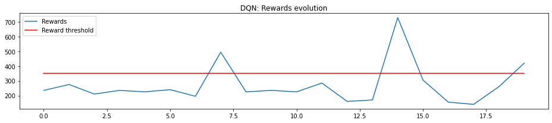

```python
##TODO: realizar las gráficas que se piden
fig, ax = plt.subplots(1, 1, figsize=(13, 3))

ax.set_title('DQN: Rewards evolution')
ax.plot(rewards)
ax.plot(thresholds, color = 'red')
ax.legend(['Rewards', 'Reward threshold'], loc = 'upper left')

plt.tight_layout()
```

**Análisis 2.13 (0.1 pto):** Almacena una partida de ejemplo del agente en la carpeta videos en formato GIF para poder visualizar su comportamiento (se da el código hecho) y comenta el comportamiento del agente entrenado.

```python
env = gym.make('SpaceInvaders-v4', render_mode='rgb_array')
def save_agent_gif(env, ag, nombre_fichero):
    '''
    :param env:  entorno GYM
    :param ag:  agente entrenado
    :param nombre_fichero:  nombre del fichero
    :return:
    '''
    frames = []
    env.reset()
    observation = env.reset()
    incio_juego = preprocess_observation(observation)
    state= stack_frame(None, incio_juego, True)
    total_reward = 0
    t=0
    while True:
            state= stack_frame(state, preprocess_observation(observation), False)
            frame = env.render(mode='rgb_array')
            frames.append(_label_with_text(frame))
            action = ag.main_network.get_action(state,epsilon=0.0)
            observation, reward, done, info = env.step(action)
            total_reward += reward
            t=t+1
            if done:
                break

    env.close()
    try:
        os.makedirs('videos')
    except:
        pass
    imageio.mimwrite(os.path.join('./videos/', nombre_fichero), frames, fps=60)

save_agent_gif(env,agentDQN, 'agente_dqn.gif')
```

**Respuesta:**  
Las recompensas obtenidas se encuentran en el entorno de *200* y *300*, mayoritariamente por debajo del umbral. Esto, además de algunos picos obtenidos, es una muestra de que el aprendizaje del agente no ha resultado ser muy robusto.

Puede ser que el resultado sea muy parecido al siguiente GIF. No os preocupéis, con los parámetros escogidos es difícil obtener unos mejores resultados.

[figure not shown]

## 3. Agente Dueling DQN (2.2 ptos)

En este apartado resolveremos el mismo entorno con las mismas características para el agente, pero usando una dueling DQN. Como en el caso anterior, primero definiremos el modelo de red neuronal, luego describiremos el comportamiento del agente, lo entrenaremos y, finalmente, testearemos el funcionamiento del mismo.

### 3.1 Definición de la arquitectura de la red neuronal

El objetivo principal de las dueling DQN es "ahorrarse" el cálculo del valor de Q en aquéllos estados en los que es irrelevante la acción que se tome. Para ello se descompone la función Q en dos componentes:

$$Q(s, a) = A(s, a) + V (s)$$

Esta descomposición se realiza a nivel de la arquitectura de la red neuronal. Las primeras capas que teníamos en la DQN serán comunes, y luego la red se dividirá en dos partes separadas definidas por el resto de capas.

La descomposición en sub-redes del modelo de la DQN implementada en el apartado anterior, será entonces:

1. Bloque común, la red CNN
2. Red advantage A(s,a):
- Una primera capa completamente conectada (representada en pytorch por nn.Lineal) de 512 neuronas, con activación ReLU
- Una última capa completamente conectada. Esta será nuestra capa de salida y por lo tanto el número de neuronas de salida dependerá del tipo de red, A(s,a) en este caso, y tendrá tantas neuronas como dimensiones tenga el espacio de acciones.
3. Red value V(s):
- Una primera capa completamente conectada (representada en pytorch por nn.Lineal) de 512 neuronas, con activación ReLU
- Una última capa completamente conectada. Esta será nuestra capa de salida con un valor por estado.

**Ejercicio 3.1 (0.75 ptos):** Implementar la clase `duelingDQN()`. Inicializar las variables necesarias y definir el modelo Funcional de red neuronal indicado.  
-----------------------------------------------------------------------------------------------------------  
**Nota**: se os proporciona el código pre-implementado. La implementación que se pide en el enunciado está indicada en los bloques *TODO* y/o con variables igualadas a *None*.

```python
class duelingDQN(torch.nn.Module):
    ###################################
    ###TODO: inicialización y modelo###
    def __init__(self, env, learning_rate=1e-3):
        """
        Params
        ======
        input_shape: tamaño del espacio de estados
        n_outputs: tamaño del espacio de acciones
        actions: array de acciones posibles
        device: cpu o cuda
        red_cnn: definición de la red convolucional
        value: definición de la red lineal value
        advantage: definición de la red lineal advantage
        """
        ###################################
        ####TODO: Inicializar variables####
        super(duelingDQN, self).__init__()
        self.input_shape = (4, 84, 84)
        self.n_outputs = env.action_space.n
        self.actions = [i for i in range(env.action_space.n)]

        if torch.cuda.is_available():
            self.device = 'cuda'
        else:
            self.device = 'cpu'

        #######################################
        ##TODO: Construcción de la red neuronal
        self.red_cnn = nn.Sequential(

            nn.Conv2d(in_channels = 4, out_channels = 32, kernel_size = 8, stride = 4),
            nn.ReLU(),
            nn.Conv2d(in_channels = 32, out_channels = 64, kernel_size = 4, stride = 2),
            nn.ReLU(),
            nn.Conv2d(in_channels = 64, out_channels = 64, kernel_size = 3, stride = 1),
            nn.ReLU()

        )

        if torch.cuda.is_available():
            self.red_cnn.cuda()

        self.fc_layer_inputs = self.feature_size()

        self.advantage = nn.Sequential(

            nn.Linear(self.fc_layer_inputs, 512),
            nn.ReLU(),
            nn.Linear(512, self.n_outputs)

        )

        self.value = nn.Sequential(

            nn.Linear(self.fc_layer_inputs, 512),
            nn.ReLU(),
            nn.Linear(512, 1)

        )

        ### Se ofrece la opción de trabajar con cuda
        if self.device == 'cuda':
            self.value.cuda()
            self.advantage.cuda()

        ### Inicializamos el optimizador
        self.optimizer = optim.Adam(self.parameters(), lr=learning_rate)

    #######################################
    #####TODO: función forward#############
    def forward(self, x):
        x_cnn = self.red_cnn(x)
        x_advantage = self.advantage(x_cnn.reshape(-1,  self.fc_layer_inputs))
        x_value = self.value(x_cnn.reshape(-1,  self.fc_layer_inputs))

        return x_value + (x_advantage - x_advantage.mean(dim=1, keepdim=True))

    ### Método e-greedy
    def get_action(self, state, epsilon=0.05):
        if np.random.random() < epsilon:
            action = np.random.choice(self.actions)  # acción aleatoria
        else:
            qvals = self.get_qvals(state)  # acción a partir del cálculo del valor de Q para esa acción
            action= torch.max(qvals, dim=-1)[1].item()
        return action


    def get_qvals(self, state):
        if type(state) is tuple:
            state = np.array(state)
        state_t = torch.FloatTensor(state).to(device=self.device)
        return self.forward(state_t)


    def feature_size(self):
        return self.red_cnn(autograd.Variable(torch.zeros(1, *self.input_shape)).to(device=self.device)).view(1, -1).size(1)
```

Para el buffer de repetición de experiencias podemos usar exactamente la misma clase experienceReplayBuffer descrita en el apartado anterior de la DQN.

### 3.2 Definición del agente

La diferencia entre la DQN y la dueling DQN se centra, como hemos visto, en la definición de la arquitectura de la red. Pero el proceso de aprendizaje y actualización es exactamente el mismo. Así, podemos recuperar la clase implementada en el apartado anterior, DQNAgent() y reutilizarla aquí bajo el nombre de duelingDQNAgent(). Lo único que deberemos hacer es añadir el optimizador entre las variables a declarar y adaptar la función de pérdida al formato Functional de pytorch.

**Ejercicio 3.2 (0.5 pto):** Implementar la clase `duelingDQNAgent()` como la `DQNAgent()`

De nuevo, durante el proceso se deben almacenar (*):

- Las recompensas obtenidas en cada paso del entrenamiento
- Las recompensas medias de los 100 episodios anteriores
- La pérdida durante el entrenamiento
- La evolución de epsilon a lo largo del entrenamiento

-----------------------------------------------------------------------------------------------------------  
**Nota**: se os proporciona el código pre-implementado. La implementación que se pide en el enunciado está indicada en los bloques *TODO* y/o con variables igualadas a *None*, salvo (*) en qué momento almacenar las variables que se indican.

```python
class duelingDQNAgent:
 ###################################################
    ######TODO 1: declarar variables ##################
    def __init__(self, env, main_network,
                 buffer, reward_threshold,
                 epsilon=0.1, eps_decay=0.99, batch_size=32, nblock=100):
        """"
        Params
        ======
        env: entorno
        dnnetwork: clase con la red neuronal diseñada
        target_network: red objetivo
        buffer: clase con el buffer de repetición de experiencias
        epsilon: epsilon
        eps_decay: epsilon decay
        batch_size: batch size
        nblock: bloque de los X últimos episodios de los que se calculará la media de recompensa
        reward_threshold: umbral de recompensa definido en el entorno
        """
        if torch.cuda.is_available():
            self.device = 'cuda'
        else:
            self.device = 'cpu'
        self.env = env
        self.main_network = main_network
        self.target_network = deepcopy(main_network) # red objetivo (copia de la principal)
        self.buffer = buffer
        self.epsilon = epsilon
        self.eps_decay = eps_decay
        self.batch_size = batch_size
        self.nblock = nblock
        self.reward_threshold = reward_threshold
        self.initialize()

    ###############################################################
    #####TODO 2: inicialitzar variables extra que es necessiten######
    def initialize(self):
        self.sync_eps = []
        self.total_reward = 0
        self.step_count = 0
        incio_juego = preprocess_observation(self.env.reset())
        self.state0 = stack_frame(None, incio_juego, True)
        self.update_loss = []
        self.epsilons = []
        self.training_rewards = []
        self.losses = []

    #################################################################################
    ######TODO 3:  Tomar nueva acción ###############################################
    def take_step(self, eps = 0.05, mode='train'):
        if mode == 'explore':
            action = self.env.action_space.sample()  # acción aleatoria en el burn-in
        else:
            action = self.main_network.get_action(self.state0, eps)# acción a partir del valor de Q (elección de la acción con mejor Q)
            self.step_count += 1

        #TODO: Realización de la acción y obtención del nuevo estado y la recompensa
        new_state, reward, done, _ = env.step(action)
        new_state = stack_frame(self.state0, preprocess_observation(new_state), False) #Recordar preprocesar los estados
        self.total_reward += reward
        self.buffer.append(self.state0, action, reward, done, new_state) # guardar experiencia en el buffer
        self.state0 = new_state

        #TODO: resetear entorno 'if done'
        if done:
            incio_juego = preprocess_observation(self.env.reset())
            self.state0 = stack_frame(None, incio_juego, True)

        return done

    ## Entrenamiento
    def train(self, gamma=0.99, max_episodes=50000,
              batch_size=32,
              dnn_update_frequency=4,
              dnn_sync_frequency=2000, min_episodios=250, min_epsilon = 0.01):
        self.gamma = gamma
        # Rellenamos el buffer con N experiencias aleatorias ()
        print("Filling replay buffer...")
        while self.buffer.burn_in_capacity() < 1:
            self.take_step(self.epsilon, mode='explore')

        episode = 0
        training = True
        print("Training...")
        maximo = 0
        while training:
            self.state0 = stack_frame(None, preprocess_observation(self.env.reset()), True)
            self.total_reward = 0
            gamedone = False
            while gamedone == False:
                # El agente toma una acción
                gamedone = self.take_step(self.epsilon, mode='train')

                #################################################################################
                #####TODO 4: Actualizar la red principal según la frecuencia establecida  #######
                if self.step_count % dnn_update_frequency == 0:
                    self.update()

                ########################################################################################
                ###TODO 6: Sincronizar red principal y red objetivo según la frecuencia establecida#####
                if self.step_count % dnn_sync_frequency == 0:
                    self.target_network.load_state_dict(self.main_network.state_dict())

                if gamedone:
                    episode += 1
                    ##################################################################
                    ########TODO: Almacenar epsilon, training rewards i loss#######
                    self.epsilons.append(self.epsilon)
                    self.training_rewards.append(self.total_reward)
                    self.losses.append(self.update_loss)

                    self.update_loss = []

                    #######################################################################################
                    ###TODO 7: calcular la media de recompensa de los últimos X episodios, y almacenar#####
                    mean_rewards = np.mean(self.training_rewards[-nblock:])
                    maximo = max(self.training_rewards[-nblock:])

                    print("\rEpisode {:d} Mean Rewards {:.2f} Epsilon {} , Maximo {:.2f}\t\t".format(
                        episode, mean_rewards, self.epsilon,maximo), end="")

                    # Comprobar si se ha llegado al máximo de episodios
                    if episode >= max_episodes:
                        training = False
                        print('\nEpisode limit reached.')
                        break


                    # Termina el juego si la media de recompensas ha llegado al umbral fijado para este juego
                    # y se ha entrenado un mínimo de episodios
                    if mean_rewards >= self.reward_threshold and min_episodios <  episode:
                        training = False
                        print('\nEnvironment solved in {} episodes!'.format(
                            episode))
                        break

                    #################################################################################
                    ######TODO 8: Actualizar epsilon ########
                    self.epsilon = max(self.epsilon * self.eps_decay, min_epsilon)


     ## Cálculo de la pérdida
    def calculate_loss(self, batch):
        # Separamos las variables de la experiencia y las convertimos a tensores
        states, actions, rewards, dones, next_states = [i for i in batch]
        rewards_vals = torch.FloatTensor(rewards).to(device=self.device).reshape(-1,1)
        actions_vals = torch.LongTensor(np.array(actions)).reshape(-1,1).to(
            device=self.device)
        dones_t = torch.ByteTensor(dones).to(device=self.device)

        # Obtenemos los valores de Q de la red principal
        qvals = torch.gather(self.main_network.get_qvals(states), 1, actions_vals)

        #DQN update#
        next_actions = torch.max(self.main_network.get_qvals(next_states), dim=-1)[1]
        next_actions_vals = next_actions.reshape(-1,1).to(device=self.device)
        # Obtenemos los valores de Q de la red objetivo
        target_qvals = self.target_network.get_qvals(next_states)
        qvals_next = torch.gather(target_qvals, 1, next_actions_vals).detach()
        #####

        qvals_next[dones_t] = 0 # 0 en estados terminales

        #TODO: Calculamos ecuación de Bellman
        expected_qvals = rewards_vals + self.gamma * qvals_next

        # Modificar la función de Loss para el modo Functional######
        loss = torch.nn.MSELoss()(qvals, expected_qvals.reshape(-1,1))
        #######
        return loss



    def update(self):
        self.main_network.optimizer.zero_grad()  # eliminamos cualquier gradiente pasado
        batch = self.buffer.sample_batch(batch_size=self.batch_size) # seleccionamos un conjunto del buffer
        loss = self.calculate_loss(batch) # calculamos la pérdida
        loss.backward() # hacemos la diferencia para obtener los gradientes
        self.main_network.optimizer.step() # aplicamos los gradientes a la red neuronal
        # Guardamos los valores de pérdida
        if self.device == 'cuda':
            self.update_loss.append(loss.detach().cpu().numpy())
        else:
            self.update_loss.append(loss.detach().numpy())
```

### 3.3 Entrenamiento

A continuación entrenaremos el modelo dueling DQN con los mismos hiperparámetros con los que entrenamos la DQN.

**Ejercicio 3.3 (0.1 ptos):** Cargar el modelo de red neuronal y entrenar el agente con los mismos hiperparámetros usados para la DQN

```python
lr = 0.001
batch = 32
max_buffer = 8000
gamma = 0.99
epsilon = 1
eps_decay = 0.995
eps_min = 0.01
steps_buffer = 100
max_episodes = 3000
min_episodes = 250
frec_upd = 100
frec_sync = 5000
reward_threshold = 350
nblock = 100

network_dueling = duelingDQN(env = env,
                             learning_rate = lr
                            )

buffer = experienceReplayBuffer(memory_size = max_buffer,
                                burn_in = steps_buffer
                               )

agent_dueling = duelingDQNAgent(env = env,
                                main_network = network_dueling,
                                buffer = buffer,
                                reward_threshold = reward_threshold,
                                epsilon = epsilon,
                                eps_decay = eps_decay,
                                batch_size = batch,
                                nblock = nblock
                               )

agent_dueling.train(gamma = gamma,
                    max_episodes = max_episodes,
                    batch_size = batch,
                    dnn_update_frequency = frec_upd,
                    dnn_sync_frequency = frec_sync,
                    min_episodios = min_episodes,
                    min_epsilon = eps_min
                   )
```

```
Filling replay buffer...
Training...
Episode 3000 Mean Rewards 8.60 Epsilon 0.01 , Maximo 50.00				Maximo 305.00
Episode limit reached.
```

**Ejercicio 3.4 (0.2 ptos):** Mostrar los mismos gráficos que con la DQN:

1. Recompensas obtenidas a lo largo del entrenamieno y la evolución de las recompensas medias cada 100 episodios, junto con el umbral de recompensa establecido por el entorno
2. Pérdida durante el entrenamiento
3. Evolución de epsilon a lo largo del entrenamiento

```python
dueling_dqn_rewards = agent_dueling.training_rewards
dueling_dqn_mean_rewards = []
for i in range(1, len(dueling_dqn_rewards)):
    if i < agent_dueling.nblock:
        dueling_dqn_mean_rewards.append(sum(dueling_dqn_rewards[0:i])/i)
    else:
        dueling_dqn_mean_rewards.append(sum(dueling_dqn_rewards[(i-agent_dueling.nblock):i])/agent_dueling.nblock)

dueling_dqn_reward_threshold = agent_dueling.reward_threshold
dueling_dqn_losses = agent_dueling.losses
dueling_dqn_epsilons = agent_dueling.epsilons
```

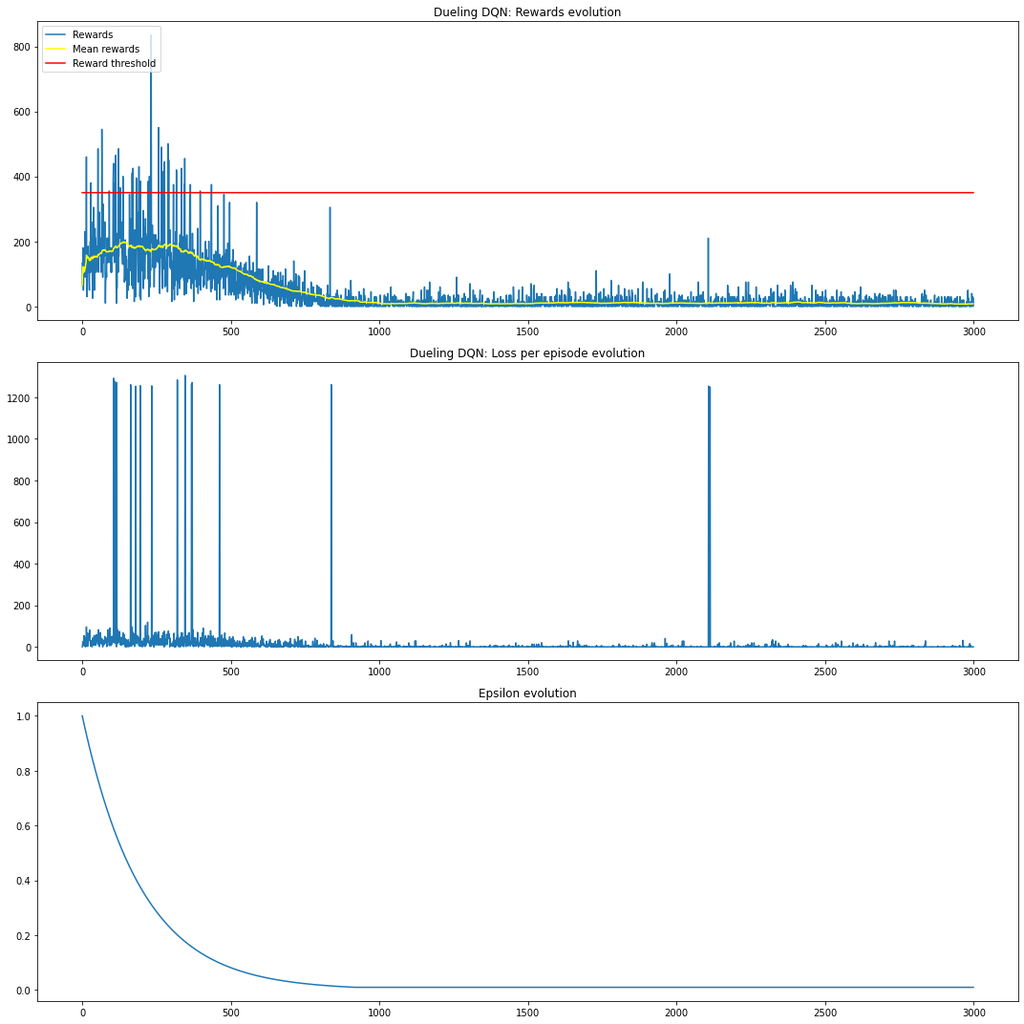

```python
fig, ax = plt.subplots(3, 1, figsize=(15, 15))

ax[0].set_title('Dueling DQN: Rewards evolution')
ax[0].plot(dueling_dqn_rewards)
ax[0].plot(dueling_dqn_mean_rewards, color='yellow')
ax[0].plot([dueling_dqn_reward_threshold for i in range(len(dueling_dqn_rewards))], color = 'red')
ax[0].legend(['Rewards', 'Mean rewards', 'Reward threshold'], loc = 'upper left')

ax[1].set_title('Dueling DQN: Loss per episode evolution')
ax[1].plot([sum(i) for i in dueling_dqn_losses])
#ax[1].ylim(0,40)

ax[2].set_title('Epsilon evolution')
ax[2].plot(dueling_dqn_epsilons)

plt.tight_layout()
```

**Análisis 3.5 (0.1 pto):** Guardar el modelo entrenado en formato ".pth" y comentar los resultados obtenidos.

```python
torch.save(agent_dueling.main_network.state_dict(), 'agentduelingDQN_Trained_Model_duelingdqn_cnn.pth')
```

**Análisis 3.6 (0.1 pto):** Comenta los resultados obtenidos

**Solución:**  
En esta caso, la diferencia entre las fases de explotación y exploración es muy acusada. A medida que epsilon decae y se comienza a explotar, las recompensas disinuyen bruscamente y se vuelven más estables (al igual que la pérdida. Esto se debe a que la fase de exploración en el entrenamiento no es lo suficientemente larga como para que el agente aprenda de forma consolidada antes de comenzar a explotar, lo que se podría solucinar con un decaimiento de epsilon menos acelerado.

### 3.4 Test del agente

Finalmente analizamos el comportamiento del agente entrenado.

**Ejercicio 3.7 (0.2 ptos):** Cargar el modelo entrenado y ejecutar el agente entrenado durante 20 episodios consecutivos. Calcular la suma de recompensas por cada episodio. Mostrar en un gráfico la suma de las recompensas respecto de los episodios, incluyendo el umbral de recompensa establecido por el entorno.

```python
agentDuelingDQN = agent_dueling
agentDuelingDQN.main_network.load_state_dict(torch.load('agentduelingDQN_Trained_Model_duelingdqn_cnn.pth'))
episodios = 20
rewards = []
thresholds = []

for i in range(episodios):
    env.reset()
    agentDuelingDQN.initialize()
    done = False
    while not done:
        done = agentDuelingDQN.take_step()

    rewards.append(agentDuelingDQN.total_reward)
    thresholds.append(agentDuelingDQN.reward_threshold)
    print("Episodio {} de {}".format(i+1, episodios), end = '\r')
```

```
Episodio 20 de 20
```

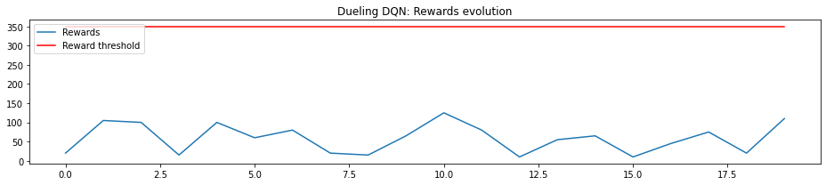

```python
fig, ax = plt.subplots(1, 1, figsize=(13, 3))

ax.set_title('Dueling DQN: Rewards evolution')
ax.plot(rewards)
ax.plot(thresholds, color = 'red')
ax.legend(['Rewards', 'Reward threshold'], loc = 'upper left')

plt.tight_layout()
```

**Análisis 3.8 (0.25 ptos):** Almacena una partida de ejemplo del agente en la carpeta videos en formato GIF para poder visualizar su comportamiento y comenta el comportamiento del agente entrenado.

```python
env = gym.make('SpaceInvaders-v4', render_mode='rgb_array')
save_agent_gif(env, agent_dueling, 'space_invader_duelingDQNAgent_comportamiento.gif')
```

## 4. REINFORCE with baseline (2 ptos)

### 4.1 Definición de la arquitectura de la red neuronal

Utilizaremos un modelo Secuencial con la siguiente configuración:

- Una primera capa del tipo Conv2d con los siguientes parámetros in_channels=(8,64,64), out_channels=32, kernel_size=8, stride=4 con activación ReLU.
- Una segunda capa del tipo Conv2d con los siguientes parámetros in_channels=32, out_channels=64, kernel_size=4, stride=2 con activación ReLU.
- Una tercera capa del tipo Conv2d con los siguientes parámetros in_channels=64, out_channels=64, kernel_size=3, stride=1 con activación ReLU.

El resultado de esta primera red lo conectaremos con un modelo complementamente conectado con la siguiente estructura lienal:

- Una primera capa completamente conectada (representada en pytorch por nn.Lineal) de 512 neuronas, bias=True y con activación Tanh
- Una última capa completamente conectada. Esta será nuestra capa de salida y, por lo tanto, tendrá tantas neuronas como dimensiones tenga nuestro espacio de acciones (una salida por cada acción posible), bias=True y activación Softmax (dim=-1).

Por último, usaremos el optimizador Adam para entrenar la red.

**Ejercicio 4.1 (0.5 ptos):** Implementar la clase `PGReinforce()`. Inicializar las variables necesarias y definir el modelo Secuencial de red neuronal indicado.  
-----------------------------------------------------------------------------------------------------------  
**Nota**: se os proporciona el código pre-implementado. La implementación que se pide en el enunciado está indicada en los bloques *TODO* y/o con variables igualadas a *None*.

```python
class PGReinforce(torch.nn.Module):

    def __init__(self, env, learning_rate=1e-3, device='cpu'):
        """
        Params
        ======
        n_inputs: tamaño del espacio de estados
        n_outputs: tamaño del espacio de acciones
        actions: array de acciones posibles
        """
        super(PGReinforce, self).__init__()
         ###################################
        ####TODO: Inicializar variables####
        self.input_shape = (4, 84, 84)
        self.n_outputs = env.action_space.n
        self.actions = [i for i in range(env.action_space.n)]
        self.device = device
        self.learning_rate = learning_rate
        ######

        #######################################
        ##TODO: Construcción de la red neuronal
        self.red_cnn = nn.Sequential(

            nn.Conv2d(in_channels = 4, out_channels = 32, kernel_size = 8, stride = 4),
            nn.ReLU(),
            nn.Conv2d(in_channels = 32, out_channels = 64, kernel_size = 4, stride = 2),
            nn.ReLU(),
            nn.Conv2d(in_channels = 64, out_channels = 64, kernel_size = 3, stride = 1),
            nn.ReLU()

        )

        if self.device == 'cuda':
            self.red_cnn.cuda()

        self.fc_layer_inputs = self.feature_size()

        self.red_lineal = nn.Sequential(

            nn.Linear(self.fc_layer_inputs, 512, bias = True),
            nn.Tanh(),
            nn.Linear(512, self.n_outputs, bias = True),
            nn.Softmax(dim = -1)

        )

        ### Se ofrece la opción de trabajar con cuda
        if self.device == 'cuda':
            self.red_lineal.cuda()

        #######################################
        ##TODO: Inicializar el optimizador
        self.optimizer = torch.optim.Adam(self.parameters(), lr=self.learning_rate)
        #####

    #Obtención de las probabilidades de las posibles acciones
    def get_action_prob(self, state):
        if type(state) is tuple:
            state = np.array(state)
        state_t = torch.FloatTensor(state).to(device=self.device)
        cnn_out = self.red_cnn(state_t).reshape(-1,  self.fc_layer_inputs)
        return self.red_lineal(cnn_out)

    def feature_size(self):
        return self.red_cnn(autograd.Variable( torch.zeros(1, * self.input_shape)).to(device=self.device)).view(1, -1).size(1)
```

### 4.2 Definición del agente

**Ejercicio 4.2 (0.55 pto):** Implementar los siguientes puntos de la clase `reinforceAgent()`:

1. Declarar las variables de la clase
2. Inicializar las variables necesarias
3. Implementar la acción a tomar
4. Calcular el *discounted reward* usando como línea de base la media estandardizada del retorno $$ \frac{x_i - \bar{x}}{\sigma_x}$$
5. Calcular la media de recompensas de los últimos 100 episodios
6. Implementar la pérdida por actualización

Además, durante el proceso se deben almacenar (*):

- Las recompensas obtenidas en cada paso del entrenamiento
- Las recompensas medias de los 100 episodios anteriores
- La pérdida durante el entrenamiento

-----------------------------------------------------------------------------------------------------------  
**Nota**: se os proporciona el código pre-implementado. La implementación que se pide en el enunciado está indicada en los bloques *TODO* y/o con variables igualadas a *None*, salvo (*) en qué momento almacenar las variables que se indican.

```python
class reinforceAgent:

    ###################################################
    ######TODO 1: declarar variables ##################
    def __init__(self, env, dnnetwork, nblock = 100, reward_threshold = 350):
        """
        Params
        ======
        env: entorno
        dnnetwork: clase con la red neuronal diseñada
        nblock: bloque de los X últimos episodios de los que se calculará la media de recompensa
        reward_threshold: umbral de recompensa definido en el entorno
        """
        self.env = env
        self.dnnetwork = dnnetwork
        self.nblock = nblock
        self.reward_threshold = reward_threshold
        self.initialize()
     #######

    ###############################################################
    #####TODO 2: inicializar variables extra que se necesiten######:
    def initialize(self):
        self.batch_rewards = []
        self.batch_actions = []
        self.batch_states = []
        self.batch_counter = 1
        self.training_rewards = []
        self.training_loss = []
        self.update_loss = []
    ######

    ## Entrenamiento
    def train(self, gamma=0.99, max_episodes=2000, batch_size=10):
        self.gamma = gamma
        self.batch_size = batch_size

        episode = 0
        action_space = np.arange(self.env.action_space.n)
        training = True
        print("Training...")
        while training:
            incio_juego = preprocess_observation(self.env.reset())
            state0 = stack_frame(None, incio_juego, True)
            episode_states = []
            episode_rewards = []
            episode_actions = []
            gamedone = False

            while gamedone == False:
                ##########################################################
                ######TODO 3:  Tomar nueva acción ########################
                action_probs = self.dnnetwork.get_action_prob(state0).detach().numpy()[0]  #distribución de probabilidad de las acciones dado el estado actual
                action = np.random.choice(action_space, p = action_probs) #acción aleatoria de la distribución de probabilidad
                next_state, reward, gamedone, _ = env.step(action)
                #######


                # Almacenamos experiencias que se van obteniendo en este episodio
                episode_states.append(state0)
                episode_rewards.append(reward)
                episode_actions.append(action)
                next_state = stack_frame(state0, preprocess_observation(next_state), False)
                state0 = next_state


                if gamedone:
                    episode += 1
                    # Calculamos el término del retorno menos la línea de base
                    self.batch_rewards.extend(self.discount_rewards(episode_rewards))
                    self.batch_states.extend(episode_states)
                    self.batch_actions.extend(episode_actions)
                    self.batch_counter += 1

                    #####################################################################################
                    ###TODO 5: calcular media de recompensas de los últimos X episodios, y almacenar#####
                    self.training_rewards.append(sum(episode_rewards))
                    mean_rewards = np.mean(self.training_rewards[-self.nblock:])
                    ######


                    # Actualizamos la red cuando se completa el tamaño del batch
                    if self.batch_counter == self.batch_size:
                        self.update(self.batch_states, self.batch_rewards, self.batch_actions)

                        ####################################
                        ###TODO : almacenar training_loss###
                        self.training_loss.append(self.update_loss)
                        ###########

                        self.update_loss = []

                        # Reseteamos las variables del epsiodio
                        self.batch_rewards = []
                        self.batch_actions = []
                        self.batch_states = []
                        self.batch_counter = 1


                    print("\rEpisode {:d} Mean Rewards {:.2f}\t\t".format(
                        episode, mean_rewards), end="")

                    # Comprobamos que todavía quedan episodios
                    if episode >= max_episodes:
                        training = False
                        print('\nEpisode limit reached.')
                        break

                    # Termina el juego si la media de recompensas ha llegado al umbral fijado para este juego
                    if mean_rewards >= self.reward_threshold:
                        training = False
                        print('\nEnvironment solved in {} episodes!'.format(
                            episode))
                        break

    ########################################################
    ###TODO 4: cálculo del retorno menos la línea de base###
    def discount_rewards(self, rewards):
        discount_r = np.zeros_like(rewards)
        timesteps = range(len(rewards))
        reward_sum = 0
        for i in reversed(timesteps):
            reward_sum = rewards[i] + self.gamma*reward_sum
            discount_r[i] = reward_sum
        baseline = (discount_r - np.mean(discount_r)) / np.std(discount_r)
        return baseline
    ##########

    ## Actualización
    def update(self, batch_s, batch_r, batch_a):
        self.dnnetwork.optimizer.zero_grad()  # eliminamos cualquier gradiente pasado
        state_t = torch.FloatTensor(batch_s)
        reward_t = torch.FloatTensor(batch_r)
        action_t = torch.LongTensor(batch_a)
        loss = self.calculate_loss(state_t, action_t, reward_t) # calculamos la pérdida
        loss.backward() # hacemos la diferencia para obtener los gradientes
        self.dnnetwork.optimizer.step() # aplicamos los gradientes a la red neuronal
        # Guardamos los valores de pérdida
        if self.dnnetwork.device == 'cuda':
            self.update_loss.append(loss.detach().cpu().numpy())
        else:
            self.update_loss.append(loss.detach().numpy())

    #################################################
    ###TODO 6: Cálculo de la pérdida#################
    # Recordatorio: cada actualización es proporcional al producto del retorno y el gradiente de la probabilidad
    # de tomar la acción tomada, dividido por la probabilidad de tomar esa acción (logaritmo natural)
    def calculate_loss(self, state_t, action_t, reward_t):
        logprob = torch.log(self.dnnetwork.get_action_prob(state_t))
        selected_logprobs = reward_t * torch.gather(logprob, 1, action_t.unsqueeze(1)).squeeze()
        loss = -torch.mean(selected_logprobs)
        return loss
     ########
```

### 4.3 Entrenamiento

A continuación entrenaremos el modelo con los siguientes hiperparámetros:

- Velocidad de aprendizaje: 0.005
- Tamaño del batch: 8
- Gamma: 0.99
- Número máximo de episodios: 5000

**Ejercicio 4.3 (0.2 ptos):** Definir los hiperparámetros, cargar el modelo de red neuronal y entrenar el agente

```python
learning_rate = 0.005
batch_size = 8
gamma = 0.99
episodes = 5000
env.reset()

r_network = PGReinforce(env = env,
                        learning_rate = learning_rate)

agent_reinforce = reinforceAgent(env = env,
                                 dnnetwork = r_network)

agent_reinforce.train(gamma = gamma,
                      max_episodes = episodes,
                      batch_size = batch_size
                     )
```

```
Training...
Episode 5000 Mean Rewards 270.00
Episode limit reached.
```

**Ejercicio 4.4 (0.1 ptos):** Mostrar los siguientes gráficos:

1. Recompensas obtenidas a lo largo del entrenamieno y la evolución de las recompensas medias cada 100 episodios, junto con el umbral de recompensa establecido por el entorno
2. Pérdida durante el entrenamiento

```python
reinforce_rewards = agent_reinforce.training_rewards
reinforce_mean_rewards = []
for i in range(1, len(reinforce_rewards)):
    if i < agent_reinforce.nblock:
        reinforce_mean_rewards.append(sum(reinforce_rewards[0:i])/i)
    else:
        reinforce_mean_rewards.append(sum(reinforce_rewards[(i-agent_reinforce.nblock):i])/agent_reinforce.nblock)
reinforce_reward_threshold = agent_reinforce.reward_threshold
reinforce_losses = agent_reinforce.training_loss
```

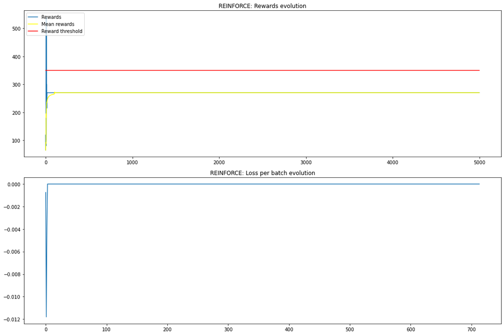

```python
fig, ax = plt.subplots(2, 1, figsize=(15, 10))

ax[0].set_title('REINFORCE: Rewards evolution')
ax[0].plot(reinforce_rewards)
ax[0].plot(reinforce_mean_rewards, color='yellow')
ax[0].plot([reinforce_reward_threshold for i in range(len(reinforce_rewards))], color = 'red')
ax[0].legend(['Rewards', 'Mean rewards', 'Reward threshold'], loc = 'upper left')

ax[1].set_title('REINFORCE: Loss per batch evolution')
ax[1].plot([sum(i) for i in reinforce_losses])
#ax[1].ylim(0,40)

plt.tight_layout()
```

**Análisis 4.5 (0.2 ptos):** Guardar el modelo entrenado en formato ".pth" y comentar los resultados obtenidos. ¿Qué ha ocurrido con este modelo?

```python
torch.save(agent_reinforce.dnnetwork.state_dict(), 'agentreinforce_Trained_Model_agentreinforce_cnn.pth')
```

**Comentarios:**  
El entrenamiento del agente converge muy rápidamente tras unos primeros episodios muy dispersos en cuanto a recompensas. Este es uno de los inconvenientes de este algoritmo al converger hacia una política óptima local y dejar de explorar el entorno. Sin embargo, las recompensas obtenidas son más altas que con los agentes anteriores, pese a realizar una nula exploración.

**Ejercicio 4.6 (0.15 ptos):** Cargar el modelo entrenado y ejecutar el agente entrenado durante 20 episodios consecutivos. Calcular la suma de recompensas por cada episodio. Mostrar en un gráfico la suma de las recompensas respecto de los episodios, incluyendo el umbral de recompensa establecido por el entorno. Comentar los resultados.

Almacena una partida de ejemplo del agente en la carpeta videos en formato GIF para poder visualizar su comportamiento y coméntalo.

```python
agentReinforce = agent_reinforce
agentReinforce.dnnetwork.load_state_dict(torch.load('agentreinforce_Trained_Model_agentreinforce_cnn.pth'))
episodios = 20
rewards = []
thresholds = []
action_space = np.arange(agentReinforce.env.action_space.n)

for i in range(episodios):
    env.reset()
    state = stack_frame(None, preprocess_observation(env.reset()), True)
    total_reward = 0
    gamedone = False
    while gamedone == False:
        action_probs = agentReinforce.dnnetwork.get_action_prob(state).detach().numpy()[0]  #distribución de probabilidad de las acciones dado el estado actual
        action = np.random.choice(action_space, p = action_probs) #acción aleatoria de la distribución de probabilidad
        next_state, reward, gamedone, _ = env.step(action)
        next_state = stack_frame(state, preprocess_observation(next_state), False)
        state = next_state
        total_reward += reward

        if gamedone:
            rewards.append(total_reward)
            thresholds.append(agentReinforce.reward_threshold)
            print("Episodio {} de {}".format(i+1, episodios), end = '\r')
```

```
Episodio 20 de 20
```

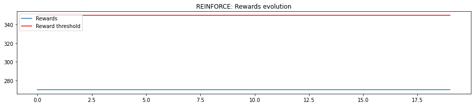

```python
fig, ax = plt.subplots(1, 1, figsize=(13, 3))

ax.set_title('REINFORCE: Rewards evolution')
ax.plot(rewards)
ax.plot(thresholds, color = 'red')
ax.legend(['Rewards', 'Reward threshold'], loc = 'upper left')

plt.tight_layout()
```

**Comentarios:**  
Como era de esperar tras converger a una política óptima a nivel local y dejar de explorar el entorno (las probabilidades de tomar una acción diferente a la que dicta dicha política son práctiamente nulas), las recompensas obtenidas son las mismas en cada uno de los 20 episodios. Aún así, es más probable obtener una recompensa más alta con este agente que con los dos anteriores.

## 5. Comparación de modelos (1 pto)

**Ejercicio 5.1 (0.5 ptos):** Muestra en un mismo gráfico la evolución de la media de recompensas de los tres modelos, junto con el umbral de recompensa.

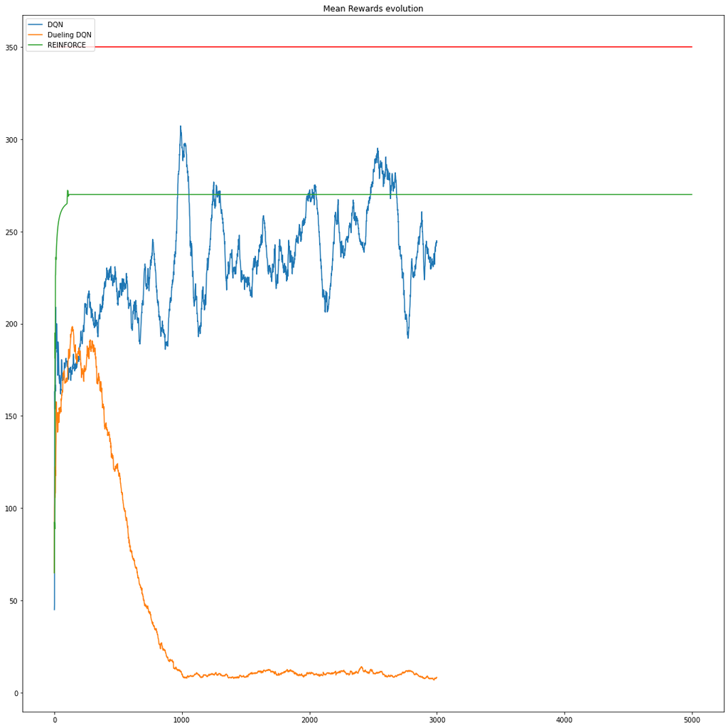

```python
fig, ax = plt.subplots(1, 1, figsize=(15, 15))

ax.set_title('Mean Rewards evolution')
ax.plot(dqn_mean_rewards)
ax.plot(dueling_dqn_mean_rewards)
ax.plot(reinforce_mean_rewards)
ax.plot([reinforce_reward_threshold for i in range(len(reinforce_mean_rewards))], color = 'red')
ax.legend(['DQN', 'Dueling DQN', 'REINFORCE'], loc = 'upper left')

plt.tight_layout()
```

**Análisis 5.2 (0.5 ptos):** Analizar los resultados obtenidos teniendo en cuenta el número de episodios, el tiempo de entrenamiento y el rendimiento de los tres agentes entrenados observado en apartados anteriores. ¿Qué agente presenta un mejor comportamiento? ¿Por qué?

**Solución (Comentarios):**  
El agente DQN es el que presenta un entrenamiento más evolutivo, pero también es el de mayor varianza. Por otro lado, el agente Dueling DQN es más consistente episodio tras epidosio, pero decae al dejar de explorar el entorno por no haber aprendido lo suficiente como para comenzar la fase de explotación. Por último, el agente REINFORCE converge muy rápidamente hacia una política que, por lo general, siempre tendrá más probabilidades de dar una recompensa más alta que los dos agentes anteriores. Por ello, este último es el que mejor rendimiento presenta.

## 6. Optimización (1 pto)

En este apartado queremos encontrar la mejor arquitectura e hiperparámetros para optimizar la precisión del modelo. Los puntos que queremos tener en cuenta para la búsqueda del mejor modelo son los siguientes:

- Número de unidades de las capas
- Learning rate
- Actualización de la red principal
- Sincronización de la red objetivo
- Batch size
- Gamma
- Número de partidas del entrenamiento

Podéis modificar o adaptar la configuración cómo consideréis oportuno siempre y cuando justifiquéis el beneficio y el cambio.

**Ejercicio 6.1 :** Elegir uno de los dos modelos de DQN implementados (DQN o dueling DQN) y experimentar con diferentes combinaciones de valores para los parámetros especificados. El objetivo es conseguir un modelo con mejores resultados que el presentado en la PEC. **Indicar** las pruebas realizadas, pero presentar **únicamente** la ejecución y resultados de la mejor opción. Justificar los valores elegidos de hiperparámetros para las distintas pruebas realizadas y comentar los resultados de entrenamiento y de rendimiento del agente entrenado.

## Búsqueda del mejor modelo

```python
n_modelos = 5
all_lr = [0.001, 0.01, 0.1]
all_frec_upd = [50, 100, 250, 400]
all_frec_sync = [2500, 5000, 7500, 9000]
all_batch = [8, 16, 32, 48]
all_gamma = [0.99, 0.9, 0.85, 0.8, 0.75]
all_max_episodes = [1500, 1200, 900, 800]

lr = []
frec_upd = []
frec_sync = []
batch = []
gamma = []
max_episodes = []
min_episodes = 200
max_buffer = 8000
epsilon = 1
eps_decay = 0.995
eps_min = 0.01
steps_buffer = 100
reward_threshold = 350
nblock = 100

agents = []

buffer = experienceReplayBuffer(memory_size = max_buffer,
                                burn_in = steps_buffer
                               )

for i in range(n_modelos):
    env.reset()
    lr.append(np.random.choice(all_lr))
    frec_upd.append(np.random.choice(all_frec_upd))
    frec_sync.append(np.random.choice(all_frec_sync))
    batch.append(np.random.choice(all_batch))
    gamma.append(np.random.choice(all_gamma))
    max_episodes.append(np.random.choice(all_max_episodes))

    if i<1:
        print('--------------------------------------- AGENTE DQN {} DE {} ---------------------------------------'.format(i+1, n_modelos))
    else:
        print('\n\n--------------------------------------- AGENTE DQN {} DE {} ---------------------------------------'.format(i+1, n_modelos))
    print('LR: {} // Actualización: {} // Sincronización: {} // Batch: {} // Gamma: {} // Max. episodios: {}'.format(lr[-1], frec_upd[-1], frec_sync[-1], batch[-1], gamma[-1], max_episodes[-1]))

    network = DQN_CNN(env = env,
                      learning_rate = lr[-1]
                     )

    agent_dqn = DQNAgent(env = env,
                     main_network = network,
                     buffer = buffer,
                     reward_threshold = reward_threshold,
                     epsilon = epsilon,
                     eps_decay = eps_decay,
                     batch_size = batch[-1],
                     nblock = nblock
                    )

    agent_dqn.train(gamma = gamma[-1],
                    max_episodes = max_episodes[-1],
                    batch_size = batch[-1],
                    dnn_update_frequency = frec_upd[-1],
                    dnn_sync_frequency = frec_sync[-1],
                    min_episodios = min_episodes,
                    min_epsilon = eps_min
                   )

    agents.append(agent_dqn)
```

```
--------------------------------------- AGENTE DQN 1 DE 5 ---------------------------------------
LR: 0.1 // Actualización: 100 // Sincronización: 5000 // Batch: 8 // Gamma: 0.99 // Max. episodios: 900
Filling replay buffer...
Training...
Episode 900 Mean Rewards 186.05 Epsilon 0.011039504743095268 , Maximo 620.00
Episode limit reached.


--------------------------------------- AGENTE DQN 2 DE 5 ---------------------------------------
LR: 0.1 // Actualización: 250 // Sincronización: 9000 // Batch: 48 // Gamma: 0.9 // Max. episodios: 800
Filling replay buffer...
Training...
Episode 800 Mean Rewards 212.35 Epsilon 0.018223908064988973 , Maximo 490.00
Episode limit reached.


--------------------------------------- AGENTE DQN 3 DE 5 ---------------------------------------
LR: 0.01 // Actualización: 50 // Sincronización: 9000 // Batch: 32 // Gamma: 0.75 // Max. episodios: 1200
Filling replay buffer...
Training...
Episode 1200 Mean Rewards 296.15 Epsilon 0.01 , Maximo 800.00		Maximo 800.00
Episode limit reached.


--------------------------------------- AGENTE DQN 4 DE 5 ---------------------------------------
LR: 0.01 // Actualización: 50 // Sincronización: 5000 // Batch: 32 // Gamma: 0.85 // Max. episodios: 800
Filling replay buffer...
Training...
Episode 800 Mean Rewards 256.40 Epsilon 0.018223908064988973 , Maximo 645.00
Episode limit reached.


--------------------------------------- AGENTE DQN 5 DE 5 ---------------------------------------
LR: 0.01 // Actualización: 400 // Sincronización: 2500 // Batch: 16 // Gamma: 0.75 // Max. episodios: 1500
Filling replay buffer...
Training...
Episode 1500 Mean Rewards 241.25 Epsilon 0.01 , Maximo 590.00		Maximo 465.00
Episode limit reached.
```

```python
all_mean_rewards = []

for a in agents:
    mean_rewards = []
    r = a.training_rewards
    for i in range(1, len(r)):
        if i < a.nblock:
            mean_rewards.append(sum(r[0:i])/i)
        else:
            mean_rewards.append(sum(r[(i-a.nblock):i])/a.nblock)
    all_mean_rewards.append(mean_rewards)
```

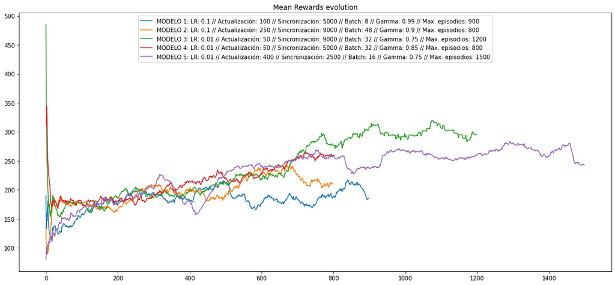

```python
fig, ax = plt.subplots(1, 1, figsize=(15, 7))
legends = []
ax.set_title('DQN Mean Rewards evolution')
for i in range(n_modelos):
    ax.set_title('Mean Rewards evolution')
    ax.plot(all_mean_rewards[i])
    legends.append('MODELO {}: LR: {} // Actualización: {} // Sincronización: {} // Batch: {} // Gamma: {} // Max. episodios: {}'.format(i+1,lr[i], frec_upd[i], frec_sync[i], batch[i], gamma[i], max_episodes[i]))
ax.legend(legends, loc = 'upper center')

plt.tight_layout()
```

## Mejor modelo: ejecución y resultados

```python
mean_of_last_100_means = [np.mean(a[-100:]) for a in all_mean_rewards]
best = np.argmax(mean_of_last_100_means)
```

```python
bestAgent = agents[best]
episodios = 20
rewards = []
thresholds = []

for i in range(episodios):
    env.reset()
    bestAgent.initialize()
    done = False
    while not done:
        done = bestAgent.take_step()

    rewards.append(bestAgent.total_reward)
    thresholds.append(bestAgent.reward_threshold)
    print("Episodio {} de {}".format(i+1, episodios), end = '\r')
```

```
Episodio 20 de 20
```

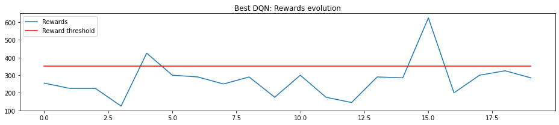

```python
fig, ax = plt.subplots(1, 1, figsize=(13, 3))

ax.set_title('Best DQN: Rewards evolution')
ax.plot(rewards)
ax.plot(thresholds, color = 'red')
ax.legend(['Rewards', 'Reward threshold'], loc = 'upper left')

plt.tight_layout()
```

```python
print('------------------------------------------ MEJOR MODELO: {} ------------------------------------------'.format(best+1))
print('LR: {} // Actualización: {} // Sincronización: {} // Batch: {} // Gamma: {} // Max. episodios: {}'.format(lr[best], frec_upd[best], frec_sync[best], batch[best], gamma[best], max_episodes[best]))
```

```
------------------------------------------ MEJOR MODELO: 3 ------------------------------------------
LR: 0.01 // Actualización: 50 // Sincronización: 9000 // Batch: 32 // Gamma: 0.75 // Max. episodios: 1200
```

```python
torch.save(bestAgent.main_network.state_dict(), 'BestDQN_Trained_Model_dqn_cnn.pth')
```

**Solución:**  
Para construir un mejor modelo cambiando los hiperparámetros, se ha descartado REINFORCE debido a su menor combinación posible de éstos, además de presentar un entrenamiento muy homogeneo a lo largo de los episodios. De entre Dueling DQN y **DQN** se ha optado por este último al presentar un entrenamiento a priori más estocástico y con mejores resultados que el primero.  
Para elegir los hiperparámetros, se han elegido 5 combinaciones aleatorias de entre los siguientes:

- Learning Rate: *0.001, 0.01, 0.1*
- Frecuencia de actualización de la red principal: *50, 100, 250, 400*
- Frecuencia de sincronización de la red objetivo: *2500, 5000, 7500, 9000*
- Tamaño del batch: *8, 16, 32, 48*
- Gamma: *0.99, 0.9, 0.85, 0.8, 0.75*
- Episodios máximos: *1500, 1200, 900, 800*

Tras entrenar los 5 modelos, se ha elegido como el mejor aquél con mayor recompensa media en los últimos 100 episodios del entrenamiento, resultando en el **modelo 3**, con los siguientes hiperparámetros:

- Learning Rate: *0.01*
- Frecuencia de actualización de la red principal: *50*
- Frecuencia de sincronización de la red objetivo: *9000*
- Tamaño del batch: *32*
- Gamma: *0.75*
- Episodios máximos: *1200*

Este modelo ha seguido un entrenamiento bastante progresivo y estable, estancándose algo en los 200 últimos episodios, pero logrando recompensas muy cercanas a los 300 puntos en estos últimos. Además, ha logrado muy buenas puntuaciones en test logrando resultados muy parecidos a los obtenidos con el modelo DQN original, con algo más de varianza pero también puntuaciones ligeramente más altas.